## Course: VISUAL ANALYTICS FOR POLICY AND MANAGEMENT

### Prof. José Manuel Magallanes, PhD

- Visiting Professor of Computational Policy at Evans School of Public Policy and Governance, and eScience Institute Senior Data Science Fellow, University of Washington.
- Professor of Government and Political Methodology, Pontificia Universidad Católica del Perú.

# Text Data

Text can be used for plotting. The plots however require some that we previously do some particular operations on the text because words can have several inflections. In this session, you will see the construction of **word clouds**. These plots represent a variation of bar plots for categories, but are attractive to the eye to show text.

1. Get the text:

Let me get a data frame with texts from some tweets:

```r
# clean memory
rm(list = ls())
link1="https://github.com/EvansDataScience/VAforPM_Text/"
link2="raw/main/trumps.csv"
trumpLink=paste0(link1,link2)
allTweets=read.csv(trumpLink ,stringsAsFactors = F)
```

The data has this columns:

```r
names(allTweets)
```

```
## [1] "created_at"     "text"           "is_retweet"     "favorite_count"
## [5] "retweet_count"  "Hour"           "Day"            "Date"
```

The Twitter text column has this information:

```r
head(allTweets$text,2)
```

```
## [1] ".@DonYoungAK really produces for Alaska. He is an incredible Congressman who loves his State and works tirelessly for it. Strong on Public Lands, Energy, and our Second Amendment. He will never let you down, and has my Complete and Total Endorsement! https://t.co/cUR3zuUfs6"
## [2] "...She will be a great Senator, and has my Complete and Total Endorsement! https://t.co/7yHPhxqQVS"
```

2. Make some selection:

This data frame has some columns that allow subsetting. In this case, I will keeping tweets that are not retweets.

```r
DTtweets=allTweets[allTweets$is_retweet==FALSE ,]
DTtweets=DTtweets[,c(1,2)]
#some
head(DTtweets,3)
```

```
##            created_at
## 1 2020-08-13 23:26:50
## 2 2020-08-13 23:23:26
## 3 2020-08-13 23:23:25
##                                                                                                                                                                                                                                                                                 text
## 1 .@DonYoungAK really produces for Alaska. He is an incredible Congressman who loves his State and works tirelessly for it. Strong on Public Lands, Energy, and our Second Amendment. He will never let you down, and has my Complete and Total Endorsement! https://t.co/cUR3zuUfs6
## 2                                                                                                                                                                                 ...She will be a great Senator, and has my Complete and Total Endorsement! https://t.co/7yHPhxqQVS
## 3                                                                  .@CynthiaMLummis is a friend of mine and a great woman. She is running for Senate in the very Special State of Wyoming. Cynthia is Strongly for our Military, our Vets, and protection of the Second Amendment...
```

3. Turn the text messages into words.

This process, also known as **tokenization**, will produce a simpler element from the input text, in this case words:

```r
library(tidytext)
library(magrittr)
DTtweets_Words = DTtweets %>%
                 unnest_tokens(output=EachWord, # column created
                               input=text,# input column from DTtweets
                               token="words") # level of unnesting

head(DTtweets_Words,10) # notice 'EachWord'
```

```
##             created_at    EachWord
## 1  2020-08-13 23:26:50  donyoungak
## 2  2020-08-13 23:26:50      really
## 3  2020-08-13 23:26:50    produces
## 4  2020-08-13 23:26:50         for
## 5  2020-08-13 23:26:50      alaska
## 6  2020-08-13 23:26:50          he
## 7  2020-08-13 23:26:50          is
## 8  2020-08-13 23:26:50          an
## 9  2020-08-13 23:26:50  incredible
## 10 2020-08-13 23:26:50 congressman
```

You have these many ‘words’:

```r
nrow(DTtweets_Words) # count of words
```

```
## [1] 3028
```

4. Getting rid of **common words**: These are know as the *STOP WORDS*:

```r
# calling the file
data(stop_words)
# seeing some 'STOP WORDS'
head(stop_words)
```

```
## # A tibble: 6 × 2
##   word      lexicon
##   <chr>     <chr>
## 1 a         SMART
## 2 a's       SMART
## 3 able      SMART
## 4 about     SMART
## 5 above     SMART
## 6 according SMART
```

Then, we remove the stop words from the *EachWord* column:

```r
library(dplyr)

 # The column 'word' from 'stop_words' will be compared # to the column 'EachWord' in 'DTtweets_Words'
DTtweets_Words = DTtweets_Words %>%anti_join(stop_words,
                                             by = c("EachWord" = "word"))

# You have these many rows now:

nrow(DTtweets_Words) # count of words
```

```
## [1] 1496
```

5. Compute **frequency** of each word:

Here, you are simply producing a frequency table. You could create a barplot with this.

```r
forCloud=as.data.frame(table(DTtweets_Words$EachWord))
names(forCloud)=c('EachWord','Counts')
#sorting by count:
forCloud_ascending=forCloud[order(forCloud$Counts),]
```

Let’s see the top and bottom of the data frame:

```r
head(forCloud_ascending,10)
```

```
##      EachWord Counts
## 1          00      1
## 2  0qex1aslcf      1
## 3  0wz3uzgiuj      1
## 5          11      1
## 6       11.5m      1
## 7         112      1
## 8       12.5m      1
## 9       13.6m      1
## 10       13.7      1
## 11      13.9m      1
```

```r
tail(forCloud_ascending,10)
```

```
##           EachWord Counts
## 167       complete     12
## 522           news     12
## 723        support     13
## 383 infrastructure     14
## 675        service     14
## 777          usdot     17
## 569         people     18
## 124            bus     20
## 360          https     54
## 729           t.co     54
```

Text, especially from tweets or similar platforms, bring unexpected *words*, so you may need to some extra cleaning manually:

```r
# dropping by text:
badWords=c('https','t.co')
forCloud_ascending=forCloud_ascending[!forCloud_ascending$EachWord%in%badWords,]

# dropping by count:
forCloud_ascending=forCloud_ascending[forCloud_ascending$Counts>4,]
```

6. Create a word cloud:

Write the code to produce the cloud below.

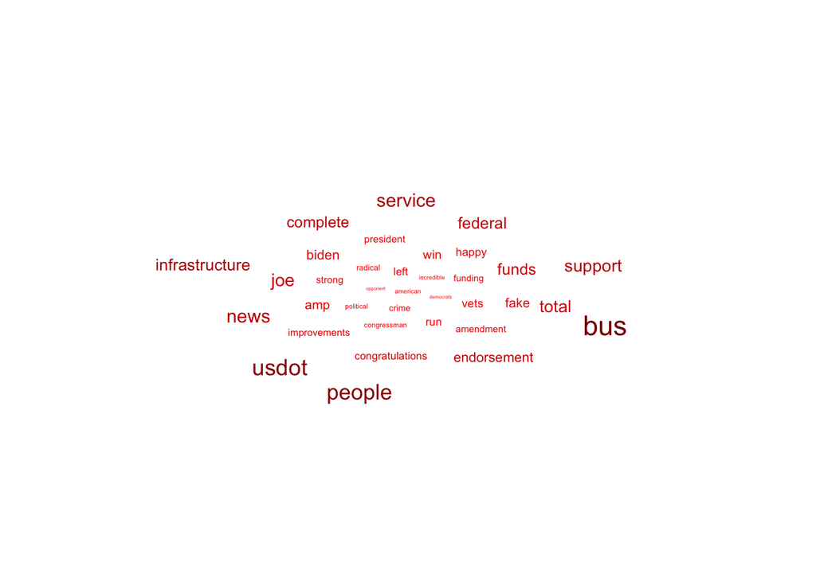

```r
library(ggwordcloud)

ggplot(forCloud_ascending,
       aes(label = EachWord, size = Counts,color = Counts)) +
    geom_text_wordcloud_area() +
    theme_minimal() +
    scale_color_gradient(low = "red", high = "darkred")
```

You can improve this using **scale_size_area()**:

[figure not shown]

```r
ggplot(forCloud_ascending, aes(label = EachWord, size = Counts,color = Counts)) +
  geom_text_wordcloud_area(eccentricity = 0.65) +
  theme_minimal() + scale_size_area(max_size = 13)+ # try increasing
  scale_color_gradient(low = "red", high = "darkred")
```

Notice that the order of the data frame with counts matters:

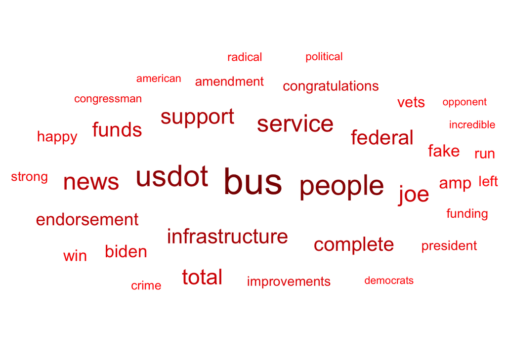

```r
forCloud_descending=forCloud_ascending[order(-forCloud_ascending$Counts),]

#now

ggplot(forCloud_descending, aes(label = EachWord, size = Counts,color = Counts)) +
  geom_text_wordcloud_area(eccentricity = 0.65) +
  theme_minimal() + scale_size_area(max_size = 13)+ # try increasing
  scale_color_gradient(low = "red", high = "darkred")
```

You do not always tweets, buy some simple text like this:

[figure not shown]

You can simply save that text as a **txt** file. Let me work with that file:

```r
otherText <- read.delim("sometext.txt",header = F)
```

Write the code to produce obtain each word:

```r
otherText_words=otherText %>%
               unnest_tokens(output=EachWord,
                             input=V1,
                             token="words")%>%
               anti_join(stop_words,
                         by = c("EachWord" = "word"))
# you get
head(otherText_words,20)
```

```
##        EachWord
## 1       seattle
## 2         siege
## 3          past
## 4       emerald
## 5          city
## 6     explosion
## 7  homelessness
## 8         crime
## 9     addiction
## 10         2017
## 11         time
## 12        count
## 13     homeless
## 14         king
## 15       county
## 16       social
## 17     services
## 18       agency
## 19         home
## 20        found
```

Now you can prepare a frequency table, let’s learn **count** from **dplyr**:

```r
txtAsc_descending=dplyr::count(otherText_words,EachWord,
                               name='Counts',
                               sort = TRUE)
# result
head(txtAsc_descending,10)
```

```
##        EachWord Counts
## 1      homeless     47
## 2  homelessness     46
## 3          city     40
## 4       seattle     37
## 5     addiction     21
## 6       percent     20
## 7        people     18
## 8        public     18
## 9      services     18
## 10      housing     16
```

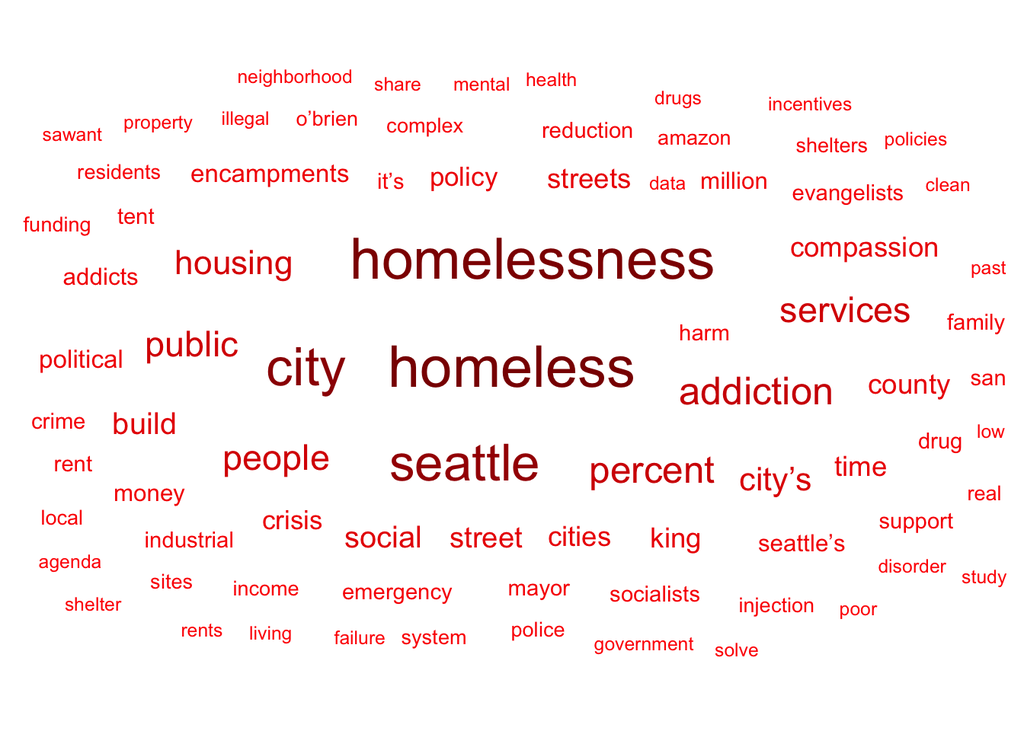

```r
# let's subset:


txtAsc_descending=txtAsc_descending[txtAsc_descending$Counts>4,]

ggplot(txtAsc_descending,
       aes(label = EachWord,
           size = Counts,color = Counts)) +
  geom_text_wordcloud() +
  scale_size_area(max_size = 10) +
  theme_minimal() +
  scale_color_gradient(low = "red", high = "darkred")
```